# instructor recap notes - lec 30

2023-12-06

```r
rm(list=ls())
# load the required libraries
library(tidyverse)
library(ggplot2)
library(dslabs)
library(broom)
library(caret)
library(tree)
library(rpart)
library(MASS)
library(randomForest)
library(glmnet)
```

## 1. Regularization method: shrinkage

Regularization methods are fundamental in machine learning to prevent overfitting and improve model generalization.

### 1.1 Motivation: Bias-Variance Trade-Off

- **What is Overfitting / Underfitting?**
- **The Bias-Variance Tradeoff**: Understanding how regularization helps to balance bias and variance.

### 1.2 Shrinkage Methods

**Why Shrinkage?**: The principle of penalizing coefficients to reduce model complexity.

#### 1.2.1 Ridge Regression (L2 Regularization)

- **Ridge Regression Overview** The term “ridge” refers to the way this penalty term modifies the optimization problem. In the space of the coefficients, the penalty term creates a ridge along which the solution must be found. This ridge imposes a constraint on the coefficients, effectively regularizing them and stabilizing the solution in the presence of multicollinearity. So, the name “ridge regression” derives from the geometrical interpretation of this regularization process, where the penalty term creates a ridge in the optimization landscape. This ridge guides the solution towards a more stable and reliable set of coefficients, even in cases where the predictor variables are highly correlated.
- Mathematical Formulation: RSS for Ridge: $\text{RSS}_{\text{Ridge}} = \sum_{i=1}^{n} (y_i - \sum_{j=1}^{p} x_{ij} \beta_j)^2 + \lambda \sum_{j=1}^{p} \beta_j^2$
- Advantages and Limitations
  - Shrinkage of Coefficients; reduce overfitting.
  - No variable selection
- **Implementation in R**

Creating a hypothetical dataset for illustration:

```r
set.seed(1206)

library(glmnet)

# Creating a hypothetical dataset called `mydata`

# Number of observations and predictors
n <- 1000 # number of observations
p <- 2000  # number of predictors
true_p <- 5

# Generating random predictors
X <- matrix(rnorm(n * p), n, p)

# Generating a response variable
noise <- rnorm(n) # random noise

# Only a few predictors influence the response, others are just noise
response <- apply(X[, 1:true_p], 1, sum) + noise

# Combining predictors and response into a data frame
mydata <- data.frame(response, X)
names(mydata) <- c("response", paste0("X", 1:p))

# View the first few rows of the dataset
# head(mydata)
```

Prepare training and testing set for ridge and lasso:

```r
# Extracting predictors and response
predictors_name <- setdiff(names(mydata), "response")

# Create training and test set
train_index <- createDataPartition(mydata$response, times = 1, p = 0.5, list = FALSE)

train_x <- as.matrix(mydata[train_index, predictors_name])
test_x <- as.matrix(mydata[-train_index, predictors_name])
train_y <- mydata$response[train_index]
test_y <- mydata$response[-train_index]
```

Fitting a ridge regression model:

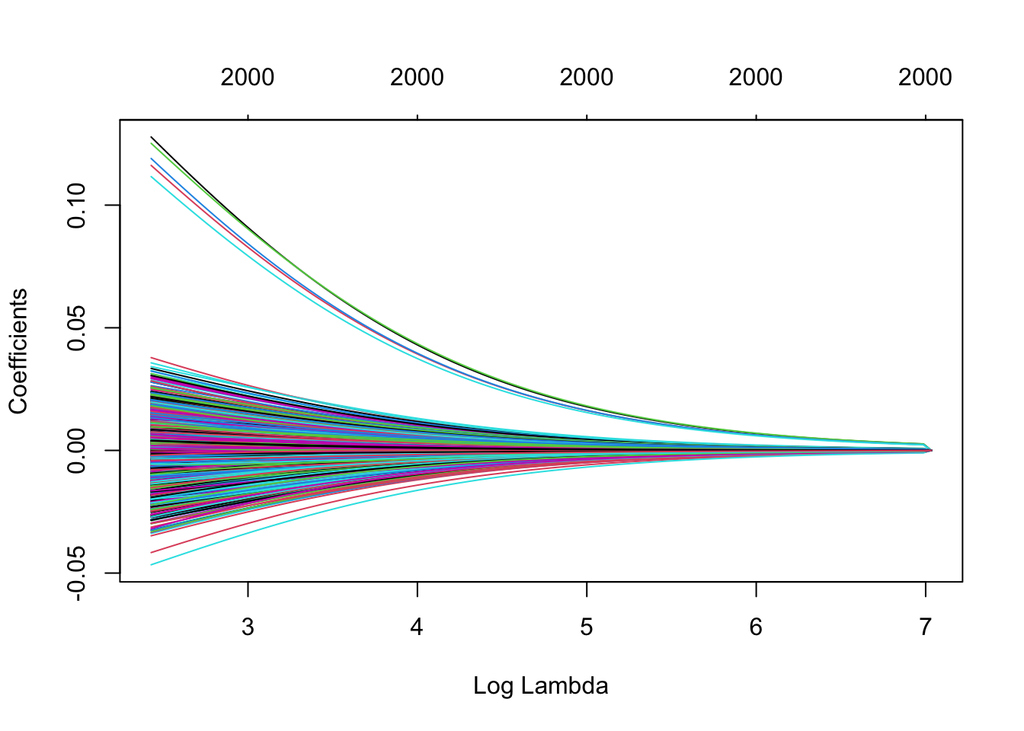

```r
fit.ridge.notune <- glmnet(train_x,
                    train_y,
                    alpha=0)

plot(fit.ridge.notune, xvar = "lambda")
```

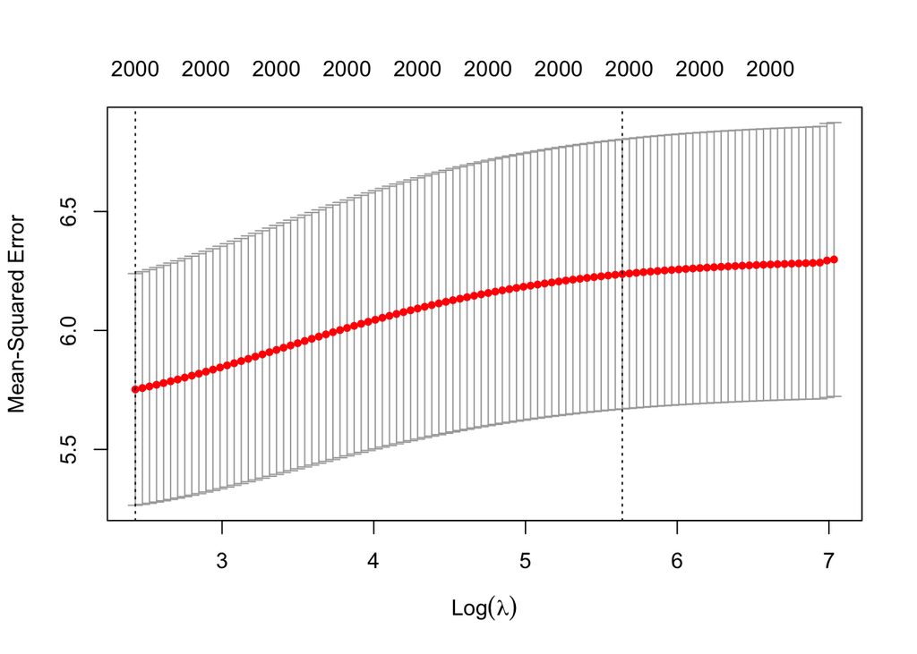

```r
# Cross-validation to find optimal lambda
cv.ridge <- cv.glmnet(train_x, train_y, alpha=0)
plot(cv.ridge)
```

```r
# Fit ridge regression with tuned lambda
fit.ridge <- glmnet(train_x,
                    train_y,
                    alpha=0,
                    lambda=cv.ridge$lambda.1se)

# Make predictions
predictions.ridge <- predict(fit.ridge,
                             s=cv.ridge$lambda.1se,
                             newx=test_x)

# Evaluation and print the evaluation metric
mse.ridge <- mean((test_y - predictions.ridge)^2)
cat("Ridge Regression MSE:", mse.ridge, "\n")
```

```
## Ridge Regression MSE: 5.33288
```

#### 1.2.2 Lasso Regression (L1 Regularization)

- **Lasso Regression Overview** “LASSO” stands for “Least Absolute Shrinkage and Selection Operator.” It’s a regression analysis method that performs both variable selection and regularization to enhance the prediction accuracy and interpretability of the statistical model it produces.
- **Mathematical Formulation**: RSS for Lasso: $\text{RSS}_{\text{Lasso}} = \sum_{i=1}^{n} (y_i - \sum_{j=1}^{p} x_{ij} \beta_j)^2 + \lambda \sum_{j=1}^{p} |\beta_j|$
- **Features**
  - Variable Selection: Lasso can shrink some coefficients to zero, effectively performing variable selection and resulting in a model that is easier to interpret.
- **Implementation in R**

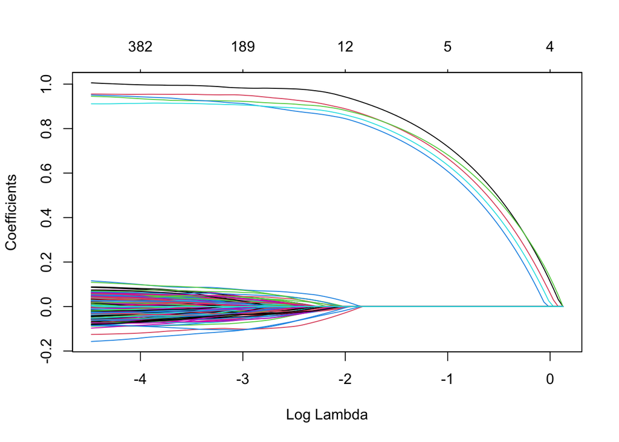

```r
fit.lasso.notune <- glmnet(train_x,
                    train_y,
                    alpha=1)

plot(fit.lasso.notune, xvar = "lambda")
```

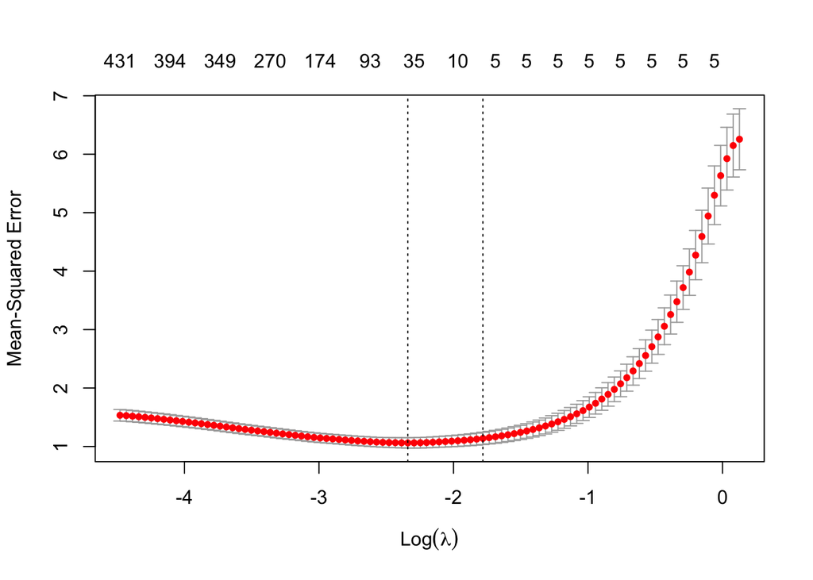

```r
# Cross-validation to find optimal lambda for lasso
cv.lasso <- cv.glmnet(train_x, train_y, alpha=1)
plot(cv.lasso)
```

```r
# Fit lasso regression with tuned lambda
fit.lasso <- glmnet(x=train_x,
                    y=train_y,
                    alpha=1,
                    lambda=cv.lasso$lambda.1se)


# Make predictions
predictions.lasso <- predict(fit.lasso,
                             s=cv.lasso$lambda.1se,
                             newx=test_x)


# Evaluation and print the evaluation metric
mse.lasso <- mean((test_y - predictions.lasso)^2)
cat("Lasso Regression MSE:", mse.lasso, "\n")
```

```
## Lasso Regression MSE: 0.9987676
```

#### 1.2.3 Differences and Similarities Between Ridge and Lasso

- **Similarities**:
  - Both methods add a penalty to the regression model to control overfitting.
  - Aim to create simpler models while maintaining prediction accuracy
- **Key Differences**:
  - Type of Penalty
  - Variable selection
  - Ridge *can* handle correlated predictors better than Lasso, which might randomly pick one of the correlated predictors.

#### 1.2.4 Elastic Net Regression (optional)

- Combining L1 and L2 Regularization
- RSS for Elastic Net: $\text{RSS}_{\text{Elastic Net}} = \sum_{i=1}^{n} (y_i - \sum_{j=1}^{p} x_{ij} \beta_j)^2 + \lambda \left( \alpha \sum_{j=1}^{p} |\beta_j| + \frac{1-\alpha}{2} \sum_{j=1}^{p} \beta_j^2 \right)$
- **Advantages of Elastic Net**: It *can* outperform Lasso in cases with highly correlated predictors.
- **Implementation in R**

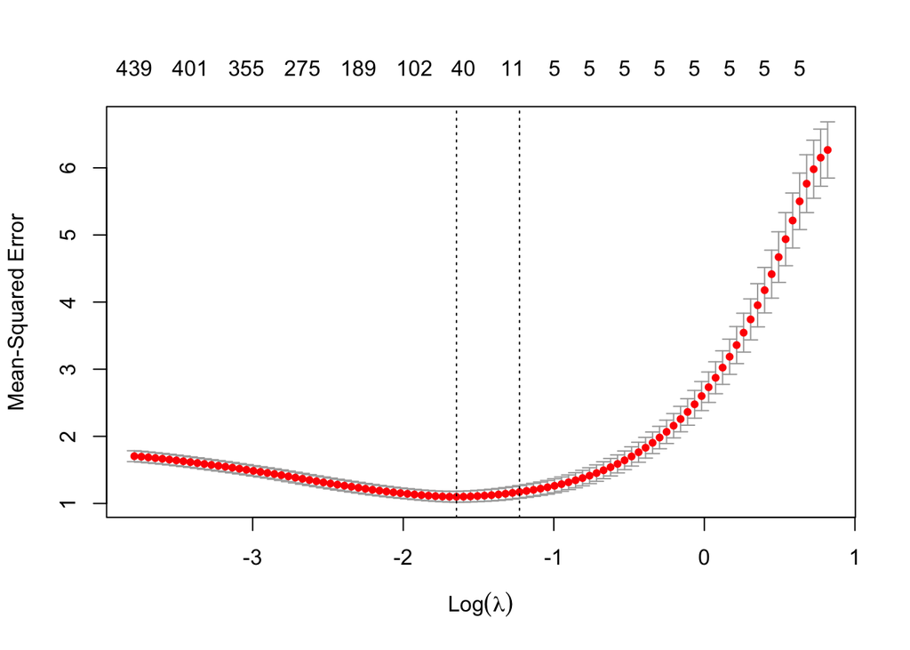

```r
# Cross-validation to find optimal lambda for elastic net
cv.elasticnet <- cv.glmnet(train_x,
                           train_y,
                           alpha=0.5) # You can adjust the alpha value
plot(cv.elasticnet)
```

```r
# Fit elastic net with tuned lambda
fit.elasticnet <- glmnet(train_x,
                         train_y,
                         alpha=0.5,
                         lambda=cv.elasticnet$lambda.1se)



# Make predictions
predictions.elasticnet <- predict(fit.elasticnet,
                                  s=cv.elasticnet$lambda.1se,
                                  newx=test_x)



# Evaluation and print the evaluation metric
mse.elasticnet <- mean((test_y - predictions.elasticnet)^2)
cat("Elastic Net MSE:", mse.elasticnet, "\n")
```

```
## Elastic Net MSE: 1.024761
```

### 1.3 Choosing the Tuning Parameter

- **Cross-Validation**: The method of choice for tuning parameter selection.

## 2. Today’s lecture

- Today: regularization (shrinkage coding with a classification example); principal component analysis
- Lab this Friday, Dec 8 (decision trees, random forest)
- Homework 4, Project, Project Peer Evaluation due on the same day